# alvin_lu_CMB710_project

2022-11-02

# Background

The data here are drawn from a study on the protein adsorbtion of nanoparticles (Walkey et al. 2014. ACS Nano, 8(3):2439{2455). They represent counts of gold nanoparticles (NPs) adsorbed by a given protein along with characteristics of the associated NP. The characteristics include diameter, core size and charge class.

# Glimpse the data

```r
glimpse(x)
```

```
## Rows: 105
## Columns: 4
## $ count      <int> 145, 57, 101, 107, 58, 66, 233, 90, 146, 131, 109, 130, 67,~
## $ npDiameter <dbl> 23.49, 47.50, 35.03, 23.04, 29.49, 23.12, 28.30, 50.95, 21.~
## $ coreSize   <fct> 14.9, 14.9, 14.9, 14.9, 14.9, 14.9, 14.9, 14.9, 14.9, 14.9,~
## $ class      <chr> "Anionic", "Cationic", "Anionic", "Anionic", "Cationic", "A~
```

# Fit poison model

```r
poi.out1 <- glm(count ~ npDiameter+coreSize+class, data = x, family = poisson(link = log))
pchi <- pchisq(poi.out1$deviance, poi.out1$df.residual,
               lower=FALSE)
```

**Lack of fit p-value is 0**.

## Plot comparison between prediction and data

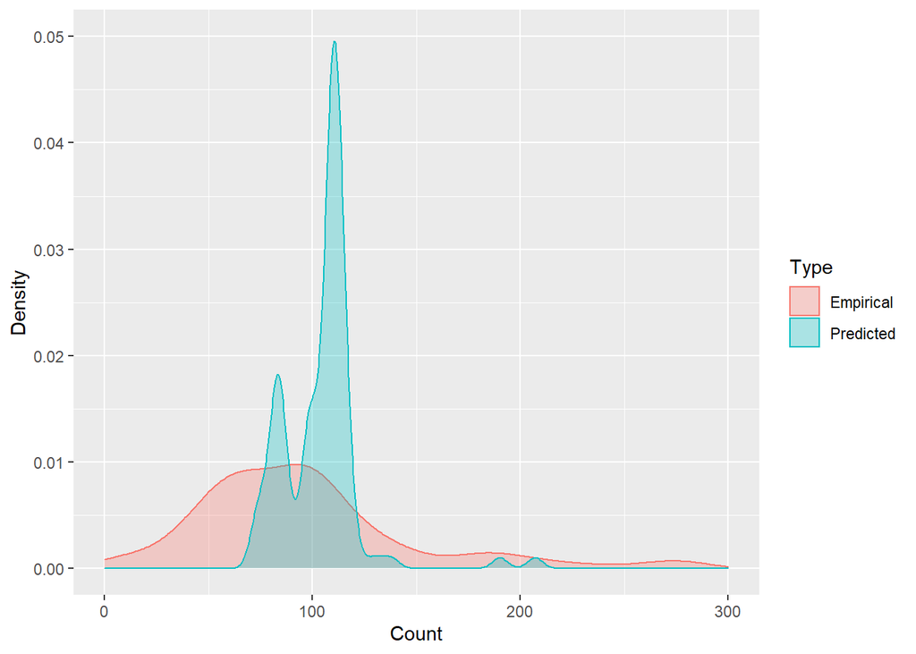

**The poisson model does not provide a good-enough fit.**

# Fit negative binomial model with interaction

```r
nb.out1<-glm.nb(count ~ npDiameter+coreSize+class+npDiameter:class, data = x,link=log)
pchi <- pchisq(nb.out1$deviance, nb.out1$df.residual,
               lower=FALSE)
```

**Lack of fit p-value is 0.1570629**.

## Plot comparison between prediction and data

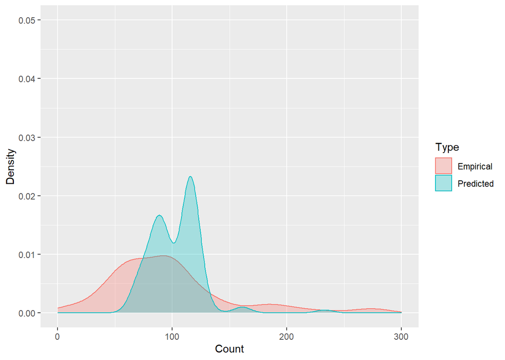

**The negative binomial model with interaction provides a better fit to the data.**

## Coefficients

```r
summary(nb.out1)$coefficient
```

```
##                               Estimate  Std. Error     z value    Pr(>|z|)
## (Intercept)               4.7442397784 0.120343063 39.42262793 0.000000000
## npDiameter                0.0004031422 0.001505145  0.26784279 0.788820332
## coreSize31.6             -0.0366659964 0.152970883 -0.23969265 0.810568533
## coreSize59.3             -0.2093354665 0.166414723 -1.25791434 0.208422736
## classCationic            -0.2785955154 0.276116427 -1.00897842 0.312984985
## classNeutral             -0.8238591793 0.303547589 -2.71410220 0.006645566
## npDiameter:classCationic -0.0000934577 0.004310264 -0.02168259 0.982701150
## npDiameter:classNeutral   0.0100961703 0.003955630  2.55235453 0.010699758
```

# Summary

The poisson models cannot provide a good fit to the model, whereas the negative binomial model gives a relatively reasonable fitting (as shown by chi-squared p-value), though the count frequency plot does not look perfect. There appears to be interaction between npDiameter and class. From the fitting results of the coefficients, only the Neutral class will have a significant effect on the count. Also only in the Neutral class does the count depends on npDiameter.